# Validation sommaire : IML-2026-020

THEBERGEA

2026-10-08 14:09

**Mission:** IML-2026-020  
**Set file:** IML2026020_set_export.csv

Note : Cette routine de validation n’effectue aucune corrections. Pour l’instant elle n’affiche que les irrégularités et propose des corrections à l’utilisateur. L’utilisateur doit manuellement effectuer les corrections dans l’application.

## Distances de draguage

Statistiques descriptives sur la distance draguée lors du relevé. La figure plus bas indique des possibles *outliers* trouvés en utilisant l’écart interquartile.

```r
summary(towDistances)
```

```
##    Min. 1st Qu.  Median    Mean 3rd Qu.    Max.
##   186.2   493.8   501.2   491.6   508.1   556.4
```

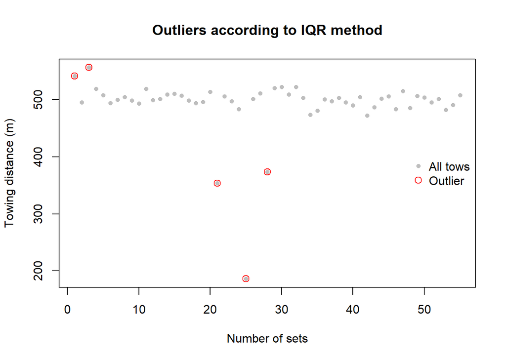

Total *outliers* repérés : 5

### Comparaison avec le positionnement du navire

Lorsque les coordonnées d’un trait de pêche sont considérées non valides la solution est d’utiliser les coordonnées enregistrées par le système de navigation du navire lui-même. La position de début et de fin de chaque coup de drague est enregistré dans le logiciel de navigation sous forme d’un *waypoint*. Ces positions n’ont pas de métadonnées en soi mais le titre du *waypoint* (*$name*) correspond à un *string* date+heure au moment de sa création.

Il est important de confirmer que les noms des *waypoints* sont bel et bien en format Eastern Time (ET) et non en UTC; le programme assume que le nom des *waypoints* correspond au fuseau horaire ET (c.-à.-d. EDT/UTC-4 en été).

```r
#ship_track <- st_read(params$ship_xycoord_path, layer="track_points")
#andes_track <- st_read(params$andes_xycoord_path, layer="track_points")
#ship_wp <- st_read(params$ship_xycoord_path, layer="waypoints")

# compute the mean time lag (shit step can take a good minute)
#timelag <- find_timelag(andes_track, ship_track)

# (!!!!!!!!!!) ERASE WHEN DONE developping
timelag <- as.difftime(48, units = "secs")

ship_wp_tow <- ship_wp_find_tow(ship_wp, mission_id)

# shift the ship's clock to match andes clock
ship_wp_time <- as.POSIXct(ship_wp_tow$name, tz = "America/toronto")
ship_wp_timecorrected <- ship_wp_time + timelag
```

Distance de dragage (m) selon les deux différentes sources de positionnement

| trait | station | distance (andes) | distance (coord navire) |
| --- | --- | --- | --- |
| 1 | 10 | 541.2819 | 446.2360 |
| 3 | 164 | 556.4213 | 493.2993 |
| 25 | 526 | 353.7902 | 499.6533 |
| 31 | 569 | 186.2199 | 426.0186 |
| 37 | 505 | 373.7384 | 389.1240 |

Comparaison des *timestamps* des deux sources positionnement

| trait | station | date début andes | date fin andes | date début navire | date fin navire | différence début | différence fin |
| --- | --- | --- | --- | --- | --- | --- | --- |
| 1 | 10 | 2026-08-17 12:18:52 UTC | 2026-08-17 12:27:29 UTC | 2026-08-17 12:19:54 UTC | 2026-08-17 12:27:15 UTC | -62 secs | 14 secs |
| 3 | 164 | 2026-08-17 13:17:46 UTC | 2026-08-17 13:26:49 UTC | 2026-08-17 13:18:40 UTC | 2026-08-17 13:27:01 UTC | -54 secs | -12 secs |
| 25 | 526 | 2026-08-20 17:16:37 UTC | 2026-08-20 17:22:05 UTC | 2026-08-20 17:14:04 UTC | 2026-08-20 17:22:07 UTC | 153 secs | -2 secs |
| 31 | 569 | 2026-08-21 12:09:52 UTC | 2026-08-21 12:13:11 UTC | 2026-08-21 12:05:54 UTC | 2026-08-21 12:13:13 UTC | 238 secs | -2 secs |
| 37 | 505 | 2026-08-21 14:34:46 UTC | 2026-08-21 14:41:23 UTC | 2026-08-21 14:34:49 UTC | 2026-08-21 14:41:30 UTC | -3 secs | -7 secs |

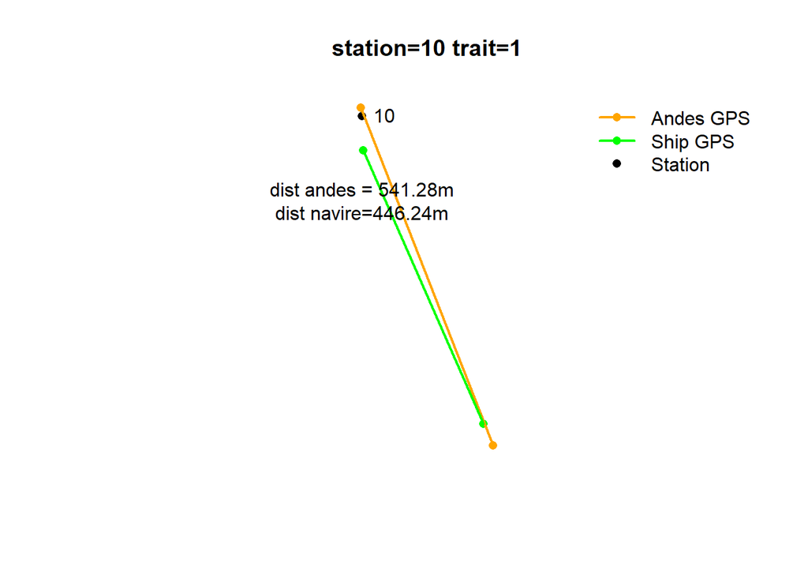

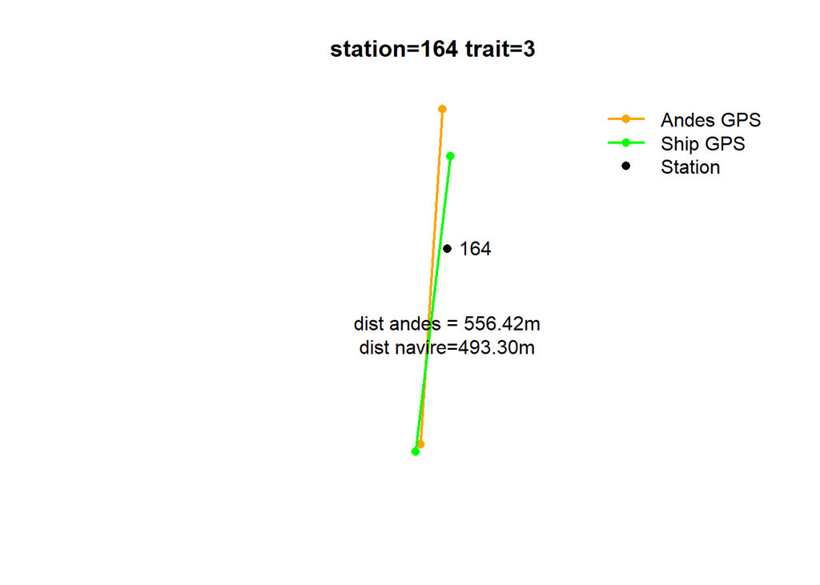

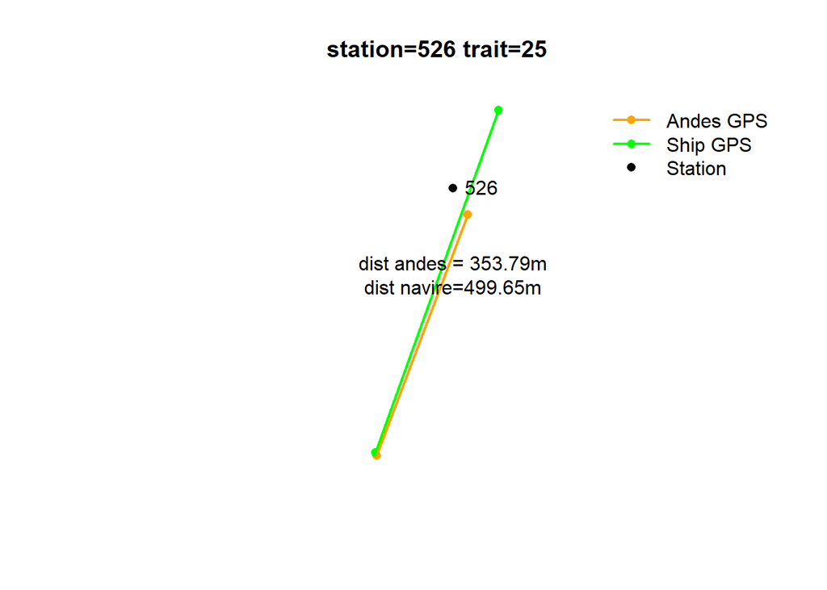

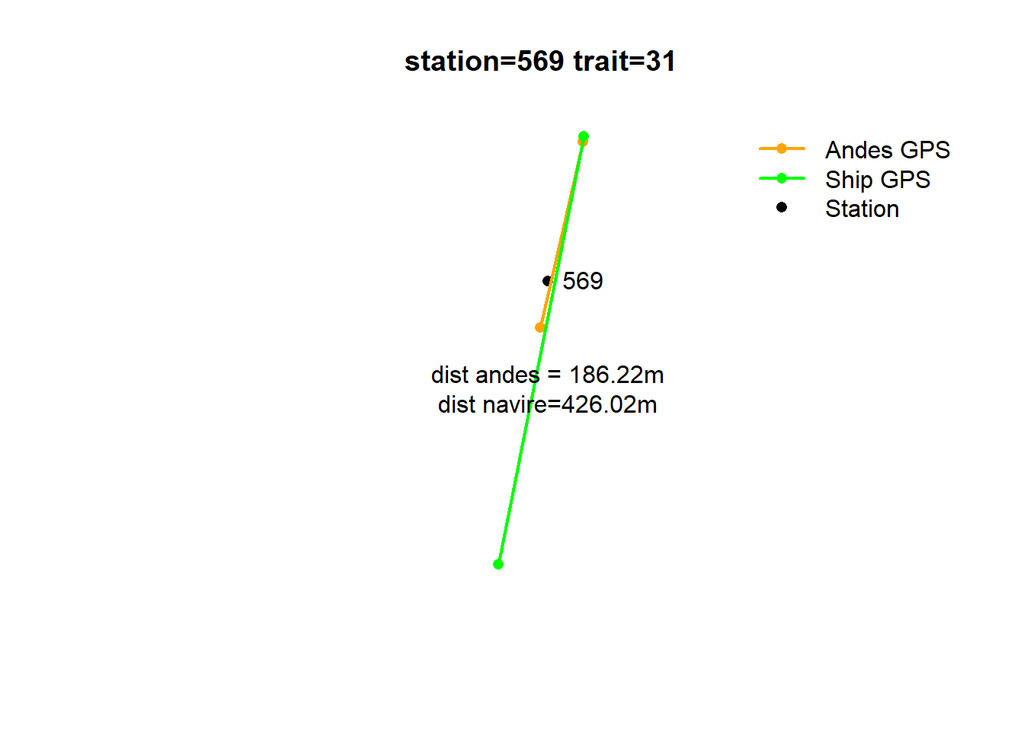

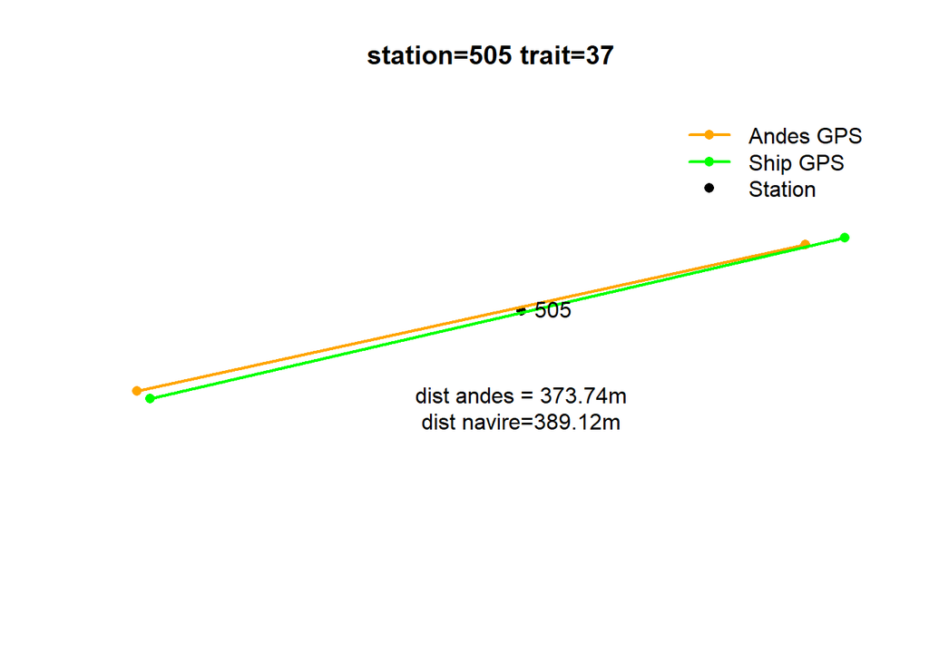

### Coordonnées suggérées

Position et timestamp suggérées

| trait | station | coord. début | coord. fin | date début (ET) | date fin (ET) |
| --- | --- | --- | --- | --- | --- |
| 1 | 10 | POINT (-61.73331 47.17455) | POINT (-61.73094 47.17087) | 2026-08-17 08:19:54 | 2026-08-17 08:27:15 |
| 3 | 164 | POINT (-61.71659 47.10971) | POINT (-61.71736 47.10531) | 2026-08-17 09:18:40 | 2026-08-17 09:27:01 |
| 25 | 526 | POINT (-62.11584 47.23429) | POINT (-62.11809 47.23007) | 2026-08-20 13:14:04 | 2026-08-20 13:22:07 |
| 31 | 569 | POINT (-62.01731 47.17251) | POINT (-62.01621 47.17627) | 2026-08-21 08:05:54 | 2026-08-21 08:13:13 |
| 37 | 505 | POINT (-62.15268 47.27457) | POINT (-62.14766 47.27536) | 2026-08-21 10:34:49 | 2026-08-21 10:41:30 |

*1- À noter que l’app. andes “Gestionnaire de station” affiche les dates selon le fuseau horaire local (ET; EDT en été).*  
*2- À noter qu’il est possible de copier une valeur en format décimal “séparateur point” dans l’app. andes lorsqu’on modifie manuellement la position d’un trait. La page suggère un format décimal “séparateur virgule” mais en réalité l’app. accepte les deux formats.*

## Coordonnées manquantes

Traits avec au moins une coordonnée manquante dans les métadonnées (“information du trait”).

| set_number | station_number | stratum | start_date | end_date | start_latitude_dd | start_longitude_dd | end_latitude_dd | end_longitude_dd | start_depth_m | end_depth_m |
| --- | --- | --- | --- | --- | --- | --- | --- | --- | --- | --- |
| 10 | 45 | Centre | 2026-08-18 15:46:42 UTC |  | 47.15884 | -61.71621 | NA | NA | 31.70 | NA |
| 14 | 179 | Centre | 2026-08-18 18:19:02 UTC |  | 47.10230 | -61.71681 | NA | NA | 32.82 | NA |
| 15 | 42 | Centre | 2026-08-18 19:21:33 UTC | 2026-08-18 19:29:31 UTC | 47.15940 | -61.76648 | NA | NA | 32.89 | 30.22 |
| 34 | 530 | Ouest | 2026-08-21 13:31:46 UTC | 2026-08-21 13:40:18 UTC | 47.22259 | -62.13225 | NA | NA | 33.10 | 32.71 |
| 52 | 98 | Centre | 2026-08-22 12:49:14 UTC | 2026-08-22 12:57:16 UTC | 47.13676 | -61.80040 | NA | NA | 34.26 | 33.89 |
| 57 | 304 | Centre | 2026-08-22 14:57:05 UTC | 2026-08-22 15:05:19 UTC | 47.09284 | -61.73018 | NA | NA | 33.02 | 32.80 |
| 61 | 218 | Centre | 2026-08-22 16:45:47 UTC | 2026-08-22 16:53:53 UTC | 47.07450 | -61.67019 | NA | NA | 32.49 | 33.03 |

Nouvelle distance de dragage (m) suggérée pour les stations avec coordonnée(s) manquante(s)

| trait | station | distance (coord navire) |
| --- | --- | --- |
| 10 | 45 | 493.4715 |
| 14 | 179 | 497.5843 |
| 15 | 42 | 503.2790 |
| 34 | 530 | 503.9209 |
| 52 | 98 | 490.9694 |
| 57 | 304 | 503.7685 |
| 61 | 218 | 496.9011 |

Nouveaux *timestamps* suggérés pour les stations avec coordonnée(s) manquante(s)

| trait | station | date début navire | date fin navire |
| --- | --- | --- | --- |
| 10 | 45 | 2026-08-18 15:46:54 UTC | 2026-08-18 15:54:23 UTC |
| 14 | 179 | 2026-08-18 18:19:13 UTC | 2026-08-18 18:27:17 UTC |
| 15 | 42 | 2026-08-18 19:21:44 UTC | 2026-08-18 19:29:45 UTC |
| 34 | 530 | 2026-08-21 13:31:52 UTC | 2026-08-21 13:40:20 UTC |
| 52 | 98 | 2026-08-22 12:49:19 UTC | 2026-08-22 12:57:20 UTC |
| 57 | 304 | 2026-08-22 14:57:11 UTC | 2026-08-22 15:05:24 UTC |
| 61 | 218 | 2026-08-22 16:45:52 UTC | 2026-08-22 16:53:59 UTC |

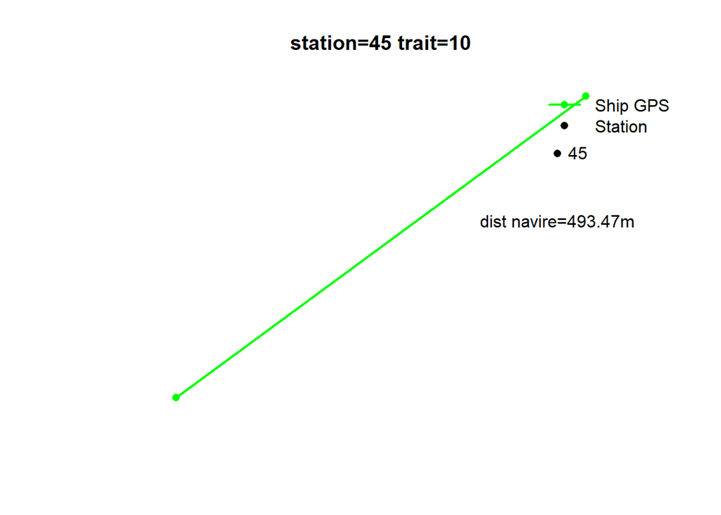

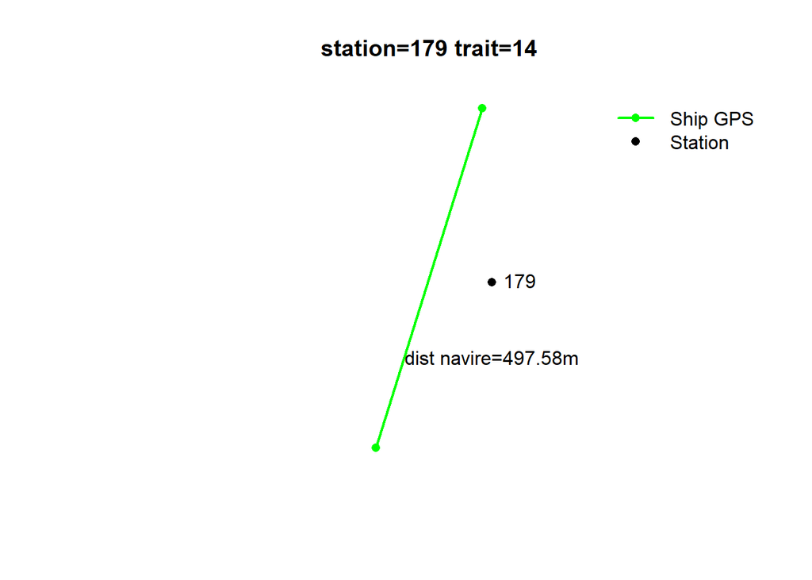

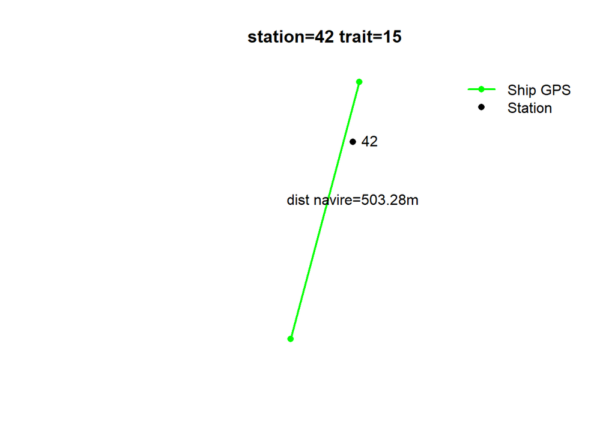

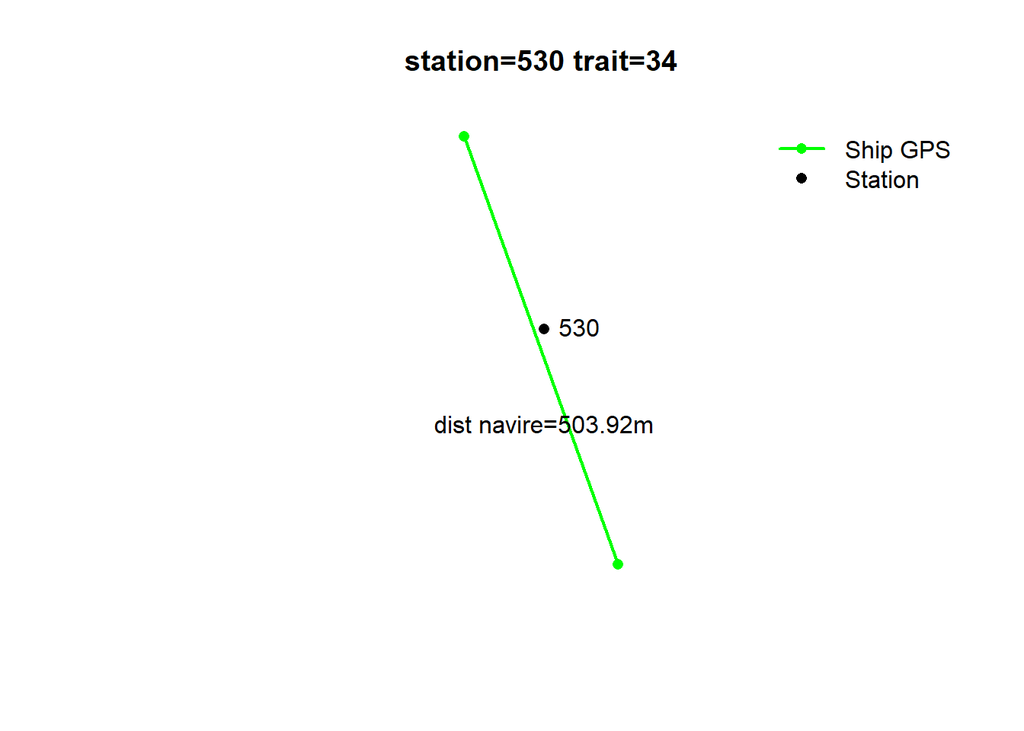

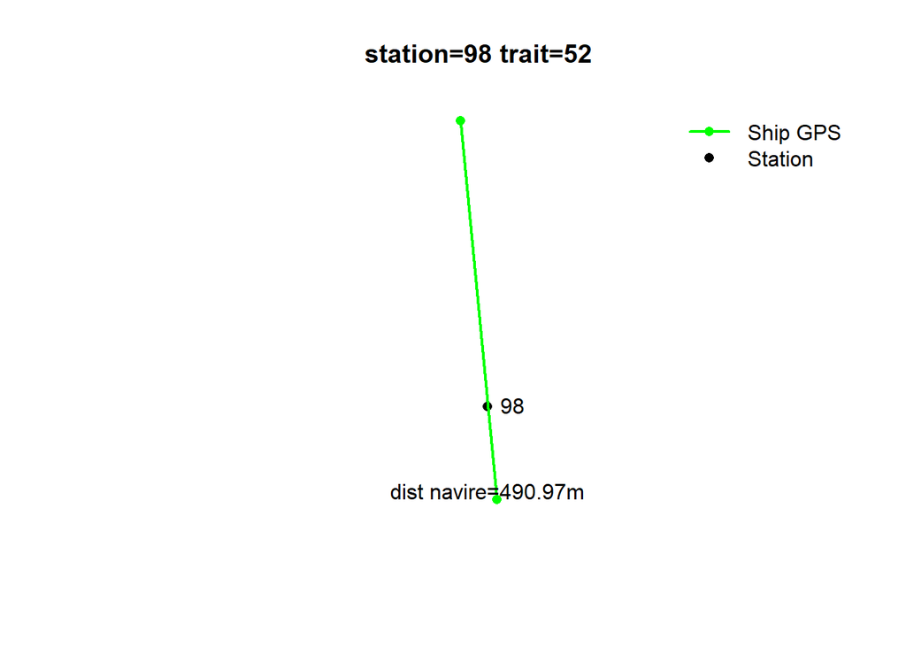

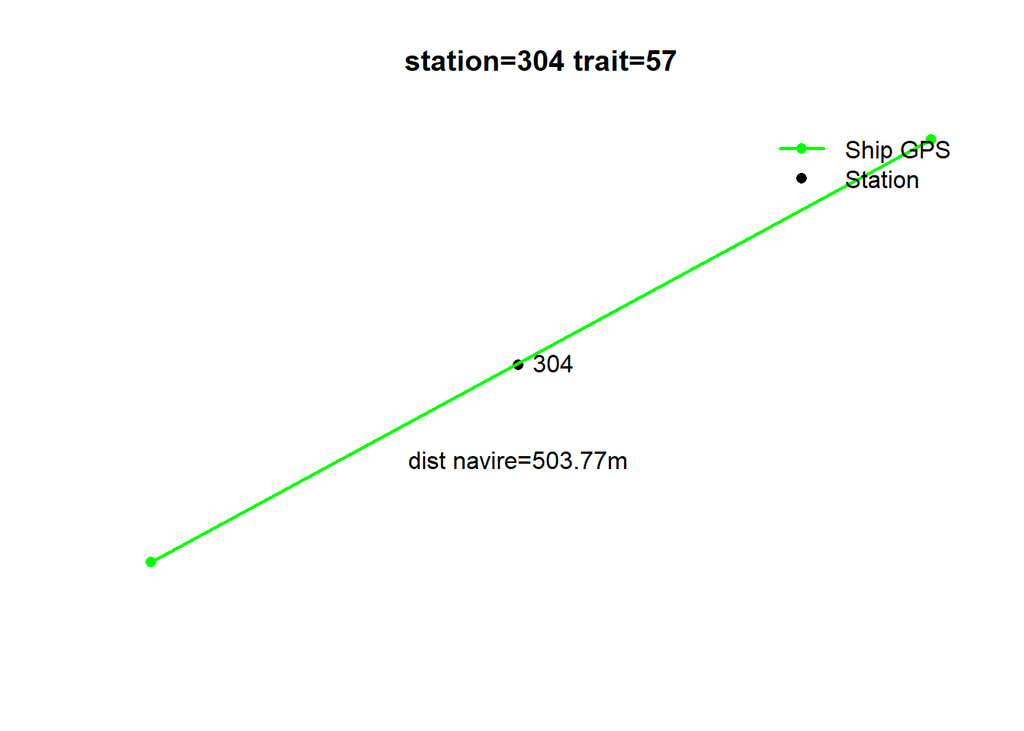

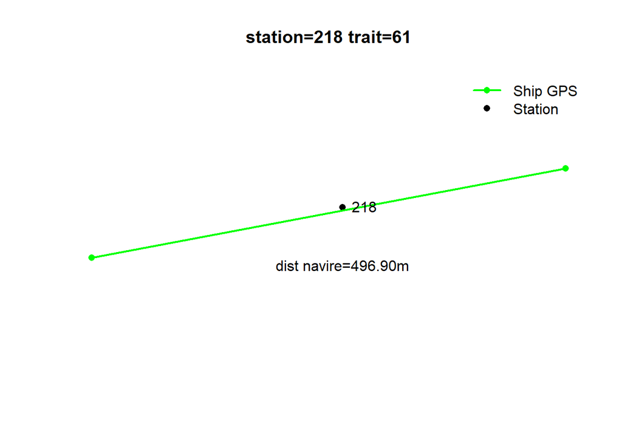

### Coordonnées suggérées

Position et timestamp suggérées

| trait | station | coord. début | coord. fin | date début (ET) | date fin (ET) |
| --- | --- | --- | --- | --- | --- |
| 10 | 45 | POINT (-61.71631 47.15883) | POINT (-61.72157 47.1562) | 2026-08-18 11:46:54 | 2026-08-18 11:54:23 |
| 14 | 179 | POINT (-61.71684 47.10218) | POINT (-61.71881 47.09791) | 2026-08-18 14:19:13 | 2026-08-18 14:27:17 |
| 15 | 42 | POINT (-61.76651 47.15935) | POINT (-61.76823 47.15497) | 2026-08-18 15:21:44 | 2026-08-18 15:29:45 |
| 34 | 530 | POINT (-62.13225 47.22265) | POINT (-62.1345 47.22691) | 2026-08-21 09:31:52 | 2026-08-21 09:40:20 |
| 52 | 98 | POINT (-61.80046 47.13665) | POINT (-61.79984 47.13225) | 2026-08-22 08:49:19 | 2026-08-22 08:57:20 |
| 57 | 304 | POINT (-61.73023 47.09282) | POINT (-61.73609 47.09066) | 2026-08-22 10:57:11 | 2026-08-22 11:05:24 |
| 61 | 218 | POINT (-61.67009 47.07453) | POINT (-61.66364 47.07536) | 2026-08-22 12:45:52 | 2026-08-22 12:53:59 |

*1- À noter que l’app. andes “Gestionnaire de station” affiche les dates selon le fuseau horaire local (ET; EDT en été).*  
*2- À noter qu’il est possible de copier une valeur en format décimal “séparateur point” dans l’app. andes lorsqu’on modifie manuellement la position d’un trait. La page suggère un format décimal “séparateur virgule” mais en réalité l’app. accepte les deux formats.*

## Profondeurs manquantes

L’application lit les données de profondeurs “brutes” (rapport : “Données du senseur”) afin de suggérer de nouvelles valeurs de profondeur. Les valeurs suggérées sont uniquement basées sur l’heure du trait.

Traits avec au moins une valeur de prof. manquante dans les métadonnées (“information du trait”).

| set_number | station_number | stratum | start_date | end_date | start_latitude_dd | start_longitude_dd | end_latitude_dd | end_longitude_dd | start_depth_m | end_depth_m |
| --- | --- | --- | --- | --- | --- | --- | --- | --- | --- | --- |
| 10 | 45 | Centre | 2026-08-18 15:46:42 UTC |  | 47.15884 | -61.71621 | NA | NA | 31.70 | NA |
| 14 | 179 | Centre | 2026-08-18 18:19:02 UTC |  | 47.10230 | -61.71681 | NA | NA | 32.82 | NA |

Comparaison de la prof.

| trait | station | prof. originale debut (m) | prof. originale fin (m) | prof trouvée debut (m) | prof trouvée fin(m) |
| --- | --- | --- | --- | --- | --- |
| 10 | 45 | 31.70 | NA | 31.70 | 32.0 |
| 14 | 179 | 32.82 | NA | 32.82 | 32.4 |

Comparaison de la date+heure

[output not shown]

Profondeurs suggérées

| trait | station | date debut (ET) | date fin (ET) | prof debut (m) | prof fin (m) |
| --- | --- | --- | --- | --- | --- |
| 10 | 45 | 2026-08-18 11:46:42 EDT | 2026-08-18 11:54:33 EDT | 31.70 | 32.0 |
| 14 | 179 | 2026-08-18 14:19:01 EDT | 2026-08-18 14:27:39 EDT | 32.82 | 32.4 |